# Technology and Social Change

Lecture 16: Revision for the Final Exam

Bogdan G. Popescu

bgpopescu@tec.mx

Tecnológico de Monterrey

# Learning Outcomes, Skills, and Themes

## Learning Outcomes of the Course (Reminder)

1. **Explain key concepts and theories** linking technological change to social, political, and economic development
2. **Compare theoretical perspectives** on how technology shapes institutions, inequality, and growth
3. **Apply theories to real-world cases**, assessing the social and political consequences of specific technologies
4. **Critically evaluate empirical claims** about technological change, identifying assumptions, evidence, and limitations
5. **Communicate** clear, well-structured arguments about technology and development in written exams, oral presentations, and class discussion

## 1. Explaining Key Concepts and Theories

- **General-purpose technology** (Bresnahan & Trajtenberg, 1995): why some technologies restructure the entire economy rather than just one task
- **Factor prices (“Why Britain?”) & Engels’ Pause** (Allen, 2009): why factor prices shape *where and whether* mechanization happens, and why growth need not raise wages
- **The task-based framework** (Acemoglu & Restrepo, 2019): why technology displaces *tasks*, not jobs, and why net employment can rise or fall
- **The productivity bandwagon** (Acemoglu & Johnson, 2023): the two conditions under which technology raises wages
- **Legibility and privacy as power** (Scott, 1998; Cohen, 2019): why technology that “sees” society shifts power toward the state

## 2. Comparing Theoretical Perspectives

Each comparison revealed something that a single theory could not:

- **Frey & Osborne (2017) vs. Arntz et al. (2016)**: counting whole *jobs* as automatable (47%) vs. counting *tasks* (9%) — the unit of analysis changes the conclusion entirely.
- **AI as complement vs. substitute**: Brynjolfsson et al. (2023) and Noy & Zhang (2023) find AI *helps* workers; Acemoglu & Restrepo (2020) find robots *replace* them. The same family of technology can do either.
- **Realism vs. Liberalism**: the security dilemma predicts an AI arms race, while complex interdependence predicts cooperation — the US–China nuclear pledge shows both forces operating at once.
- **Germany vs. USA vs. Sweden**: identical robots, opposite labor-market outcomes, showing that institutions, not the technology, decide who wins.

## 3. Applying Theories to Real-World Cases

Theory turns puzzling cases into explainable ones:

- Why did the Industrial Revolution begin in *Britain*? Allen’s (2009) factor prices: high wages + cheap coal made machines profitable there and nowhere else.
- Why did ATMs *increase* the number of bank tellers? The productivity effect in the task-based framework: cheaper branches –> more branches –> more tellers.
- Why did trade-shocked US regions turn to *populism*? Distributional conflict plus non-adjustment: displaced workers did not relocate, and the losses concentrated and persisted (Autor, Dorn & Hanson, 2013).
- Why does predictive policing *reproduce* discrimination? Performative prediction: training on arrest data creates a self-fulfilling feedback loop (Lum & Isaac, 2016).

## 4. Critically Evaluating Empirical Claims

We learned to ask: does the evidence actually support the claim? For example, we:

- Identified a **measurement error**: Frey & Osborne (2017) conflated *technical feasibility* with *economic adoption*; switching to task-level analysis cut the “47% at risk” headline to 9% (Arntz et al., 2016).
- Spotted **deep uncertainty**: three leading AI-exposure indexes (Felten, Brynjolfsson, Webb) rank the same sectors contradictorily, so claims about “which jobs AI will hit” rest on shaky measurement (Boix et al., 2026).
- Compared **competing projections**: estimates of AI’s GDP impact diverge by an order of magnitude — Acemoglu (2025, +1%) vs. Goldman Sachs (2023, +7%) — because they rest on different modeling assumptions, not different data.

## 4. Critically Evaluating Empirical Claims (cont.)

- Distinguished **correlation from causation**: the Anthropic (2025) finding that hiring of young workers slowed in AI-exposed occupations is an early warning, but it is correlational — it cannot yet prove that AI *caused* the slowdown.

## Skills Gained/Enhanced

- **Critical Thinking:** evaluate and compare competing theories of technological and social change — e.g., weighing AI as *complement* (Brynjolfsson et al., 2023) against AI as *substitute* (Acemoglu & Restrepo, 2020)
- **Analytical Skills:** analyze research questions using theory and evidence — e.g., reading the task-based framework against the China-shock and robot-adoption data
- **Effective Communication:** articulate clear, structured arguments in oral and written form, signposting and engaging authors with one another
- **Comparative Perspective:** examine political and economic outcomes across contexts — Britain vs. today, Germany vs. the USA, the Global North vs. the Global South

# What This Review Covers

## Scope of the Final

This review covers **Lectures 8 through 15**, the second half of the course:

- **L8 — The Industrial Revolution:** the first general-purpose technology shock
- **L9 — How Technologies Emerge:** technology as a self-building, evolving system
- **L11 — Labor & Automation:** how technology reshapes work and wages
- **L13 — AI, Surveillance & Human Rights:** technology and state power
- **L14 — AI & International Relations:** technology and great-power competition
- **L15 — AI & the Political Economy:** will AI deliver shared prosperity?

## The One Framework Behind All Six Lectures

Every lecture in the second half is a variation on a single chain:

**Technology –> Productivity & Power Shift –> Distributional Conflict –> Institutions Mediate –> Outcome**

Two ideas recur in *every* case:

1. **Technology is not destiny.** The same technology produces different outcomes depending on **institutions** (Acemoglu & Robinson, 2012) and **factor prices/incentives** (Allen, 2009).
2. **Gains are never shared automatically.** Whether workers, citizens, or whole nations benefit depends on **bargaining power and institutional checks**.

# Lecture 8: The Industrial Revolution

## L8: Key Concepts

- **General-Purpose Technology (GPT)** (Bresnahan & Trajtenberg, 1995): a technology that is *pervasive*, *improvable*, and *spawns new innovations*. Steam, electricity, and digital/AI are the three canonical GPTs.
- **Why Britain?** (Allen, 2009): innovation follows **factor prices**, not genius. High wages + cheap coal (i.e., expensive British labor but abundant, cheap domestic coal) made the spinning jenny profitable in Britain (30–40% return) but not elsewhere (2–3%). The *knowledge* existed everywhere; only Britain had the incentive.
- **The factory system** (Mokyr, 2002): an **organizational** innovation, not just a technical one — centralized power, supervision, time discipline (Thompson, 1967).

## L8: Engels’ Pause

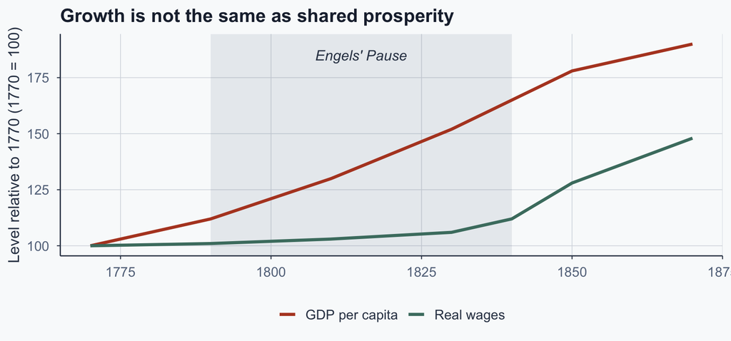

Figure 1: Britain: real wages stagnated while output surged, 1770–1870 (indexed, 1770 = 100). Stylized after Allen (2009).

**Engels’ Pause** (Allen, 2009): in **Britain**, output surged ~1790–1840, but real wages stagnated — gains went to capital. Institutions eventually responded: Factory Acts (1833–47), Mines Act (1842), Ten Hours Act (1847), mass schooling (1870s). The lag was **40–60 years**.

## L8: Potential Questions

- Using Allen’s (2009) **factor-price** argument (“Why Britain?”), explain why the Industrial Revolution began in Britain and not in equally knowledgeable societies. What role did wages and coal prices play?
- What is **Engels’ Pause**, and what does it teach us about the relationship between productivity growth and wages? Use it to assess claims that AI will automatically raise living standards.

# Lecture 9: How Technologies Emerge

## L9: Arthur’s Theory of Technology

**Brian Arthur (2009), *The Nature of Technology*:** technology is not a series of lucky inventions but a **self-building system**.

- **Technology** = “the programming of phenomena to our use.” A **phenomenon** must first be observed, then understood (science), then exploited (engineering). *Magnetism was known for 2,000 years before Faraday (1831) made it usable.*
- **Combinatorial innovation:** new technologies are assembled from existing ones (the 1886 Benz Motorwagen = engine + wheels + steering + transmission).
- **Recursive innovation:** “technology creates itself out of itself” — each new technology becomes a building block for the next, so innovation **accelerates**.

## L9: Diffusion, Lock-In, and Co-evolution

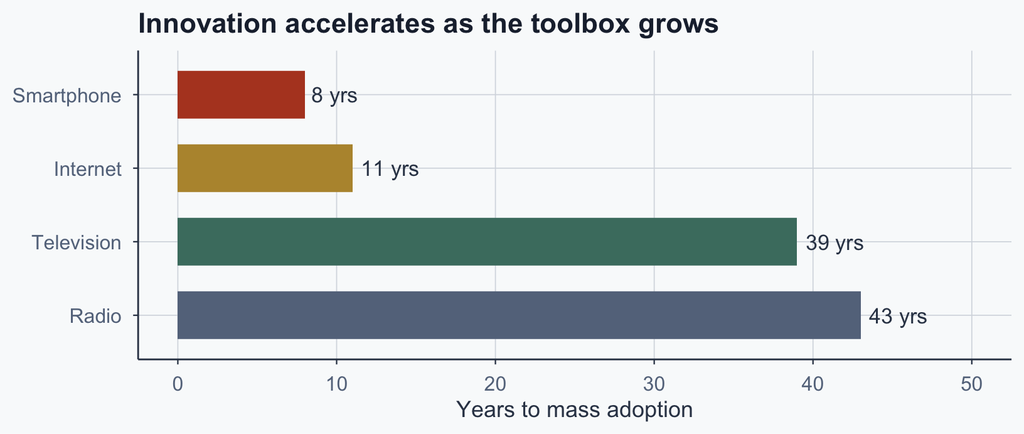

Figure 2: Years from launch to mass adoption. Each generation saturates faster (Comin & Hobijn, 2010).

- **Lock-in / path dependence** (David, 1985): QWERTY survives because of installed base, not because it is optimal.
- **Co-evolution & the double movement** (Polanyi, 1944): technology reshapes the economy, the economy reshapes society, and disruption triggers a protective **counter-movement**.

## L9: Potential Questions

- Magnetism was known for 2,000 years before it became a usable technology. Using Arthur (2009), explain why **observing** a phenomenon is not enough to **exploit** it.
- Why does new technology appear faster and faster over time? Explain using Arthur’s (2009) idea that technologies are built out of other technologies.

# Lecture 11: Labor & Automation

## L11: The Task-Based Framework

Jobs are **bundles of tasks**; technology affects tasks, not jobs directly (Acemoglu & Restrepo, 2019).

**Net employment effect = (Productivity + Reinstatement) − Displacement**

- **Displacement (−):** machines take over existing tasks
- **Productivity (+):** cheaper output expands demand (ATMs –> *more* bank branches –> more tellers)
- **Reinstatement (+):** new tasks emerge that didn’t exist before
- This is why the **“lump of labor”** fear is wrong: the amount of work is not fixed
- Frey & Osborne (2017) claimed **47%** of jobs were at risk
- Using task-level analysis, Arntz et al. (2016) corrected this to **9%**

## L11: Polarization and Skill Bias

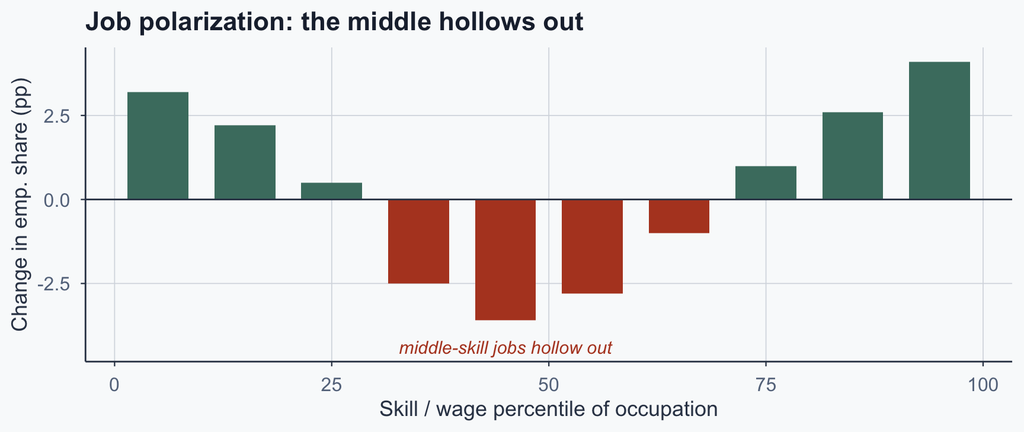

Figure 3: Change in employment share by skill percentile, US 1980–2005 (Autor & Dorn, 2013).

- **SBTC** — Skill-Biased Technological Change (Goldin & Katz, 2008): computers raise demand for skilled workers; US college premium rose 45% –> ~75%.
- **RBTC** — Routine-Biased Technological Change (Autor, Levy & Murnane, 2003): computers automate *routine* tasks –> high and low ends grow, middle shrinks.

## L11: Same Technology, Different Outcomes

**Institutional mediation:** the *same* robots produce *different* outcomes across countries.

- **Germany:** strong unions + codetermination + vocational training –> moderate inequality, job security
- **USA:** weak unions + market-led –> sharp inequality, job loss
- **Sweden:** active labor-market policy –> low inequality, smooth transitions

**The China Shock** (Autor, Dorn & Hanson, 2013):

- ~2.4 million US jobs lost, concentrated in specific regions
- Workers did *not* relocate; effects persisted >10 years
- Shifted those regions toward **populism**
- Same shock, but Auto Alley recovered (Japanese FDI) while furniture towns did not

## L11: Potential Questions

- Why does “automation will eliminate 47% of jobs” overstate the risk? Use the **task-based framework** (displacement, productivity, reinstatement) and the Frey & Osborne (2017) vs. Arntz et al. (2016) debate.
- The US and Germany adopted robots at similar rates but had very different labor outcomes. Explain why, using **institutional mediation** and **path dependence**.

# Lecture 13: AI, Surveillance & Human Rights

## L13: AI and State Power

- **Legibility** (Scott, 1998): states simplify society to control it. AI is “Seeing Like a State 2.0” — it tracks movement, networks, and emotions at near-zero cost.
- **Privacy as a power resource** (Cohen, 2019): privacy is not secrecy; it limits the **information asymmetry** between citizens and institutions. AI widens that asymmetry.
- **Performative prediction** (Lum & Isaac, 2016): predictive policing trains on **arrest** data (not crime), then sends police where it predicts — a self-fulfilling **feedback loop** that reproduces past discrimination.

## L13: Bias and the Institutional Hinge

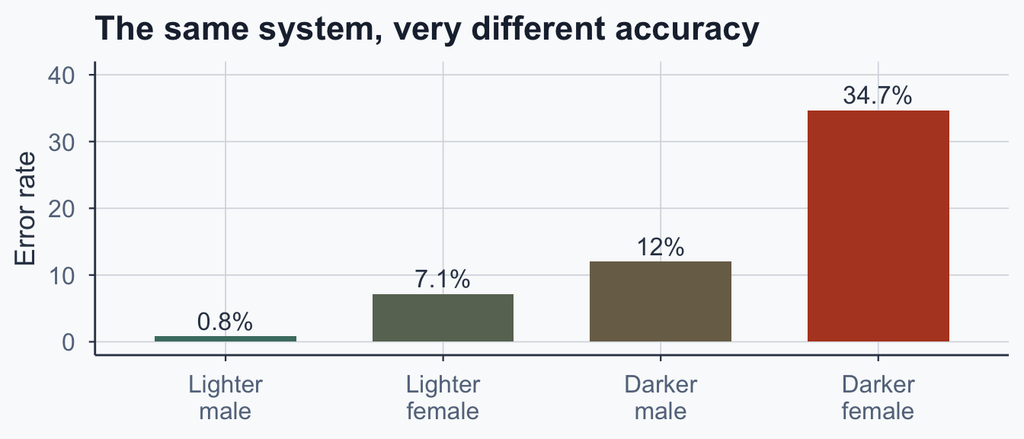

Figure 4: Facial-recognition error rates by group (Buolamwini & Gebru, 2018, Gender Shades).

**The hinge is institutions** (Boix, 2022):

- The same AI is **de-democratizing** where checks are weak (repression, exclusion)
- But it can be **re-equilibrated** where courts, media, and civil society are strong
- Contrast the Stasi (5.6m files, ended by institutional collapse) with the wrongful arrest of Robert Williams (human-in-the-loop safeguards failed)

## L13: Potential Questions

- Predictive policing is trained on arrest data, not crime data. Explain why this creates a feedback loop that **reproduces** discrimination instead of fixing it.
- Why does the same AI strengthen democracy in some countries but enable repression in others? Answer using institutions (Boix, 2022).

# Lecture 14: AI & International Relations

## L14: Three Lenses on World Politics

The three dominant IR paradigms read the *same* events differently:

| Theory | Core claim | Applied to AI |
| --- | --- | --- |
| **Realism** | Anarchy forces states to compete for power | chip export controls; the AI arms race |
| **Liberalism** | Interdependence & institutions reward cooperation | UN AI resolutions; US–China nuclear-AI pledge |
| **Constructivism** | Ideas & norms define what counts as a threat | the “AI superpower” framing; campaigns to ban killer robots |

For US–China rivalry, **Realism** does the most explanatory work — so we start there.

## L14: AI as Great-Power Competition

- **An arms race no one wants** (the *security dilemma*, Realism):
  - The US limits chips to feel safer
  - China sees a threat and races to catch up
  - The US clamps down harder
  - Each side’s *defense* looks like *aggression* to the other
- **Whoever controls the chips has the power:** the AI supply chain runs through three places —
  - *Designs* — US (Nvidia)
  - *Factories* — Taiwan (TSMC, 92% of advanced chips)
  - *Machines* — Netherlands (ASML, 100% of EUV)
  - And unlike oil, **you can’t stockpile chips**

## L14: Why a Treaty Is So Hard

- **You can’t tell if a rival is cheating** (the *verification problem*):
  - Missiles can be counted, inspected, and verified
  - But AI is just *software* — invisible, easy to copy, deployable in secret
  - So no one can prove a state is breaking the rules
- **The result:**
  - 166 countries voted to regulate killer robots (LAWS — lethal autonomous weapons)
  - But a few (e.g. Russia, North Korea) opposed
  - And **no binding treaty exists** — when cheating can’t be caught, defection wins

## L14: The Race and Its Losers

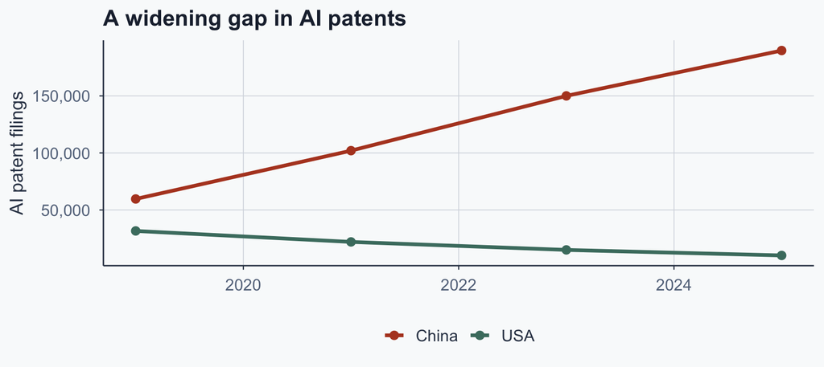

Figure 5: AI patent filings: China surges as the US declines. Endpoints from GreyB (2025); trend stylized.

- **Liar’s dividend** (Citron & Chesney, 2019): once deepfakes exist, even *real* footage can be dismissed as fake — eroding the shared facts democracies need.
- **Global South** (Boix et al., 2026): AI + reshoring may **reverse North–South convergence**; ~1.8bn jobs in developing countries are exposed. In Mexico, robot exposure shifted communities **leftward** (unlike right-populism in rich countries).

## L14: Potential Questions

- Use the **security dilemma** to explain US–China AI competition despite both preferring restraint. Why does the **verification problem** make binding arms control (e.g., LAWS) unlikely?
- How does AI-driven automation threaten development in the Global South (Boix et al., 2026)? Why might it produce different political reactions there than in advanced economies?

# Lecture 15: AI & the Political Economy

## L15: The Productivity Bandwagon

**Acemoglu & Johnson (2023):** rising productivity raises wages **only if two conditions hold**:

1. **Marginal productivity (complement, not substitute):** the technology must make workers *more* valuable, not replace them.
2. **Bargaining power:** workers must be able to *capture* the gains (unions, tight labor markets, political voice).

**When both fail, you get an Engels’ Pause** — productivity rises, wages don’t. Britain (1790–1840) failed both conditions; reforms after 1840 (legal unions, mass schooling, suffrage) restored them.

## L15: The Decoupling and the AI Evidence

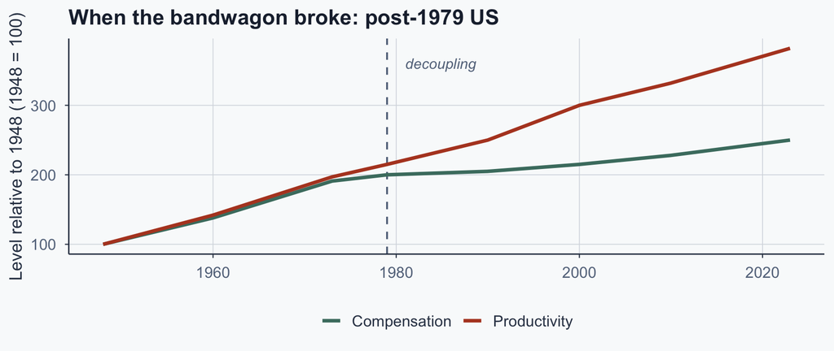

Figure 6: US productivity vs. compensation, indexed to 1948 (Economic Policy Institute, 2024).

## L15: The AI Evidence Is Mixed

- **AI can *complement* workers** (makes them more productive):
  - Call-center output **+34%** for novices (Brynjolfsson et al., 2023)
  - The writing-quality gap between weak and strong writers **shrinks** (Noy & Zhang, 2023)
- **But AI can also *substitute*** for workers (replaces them):
  - +1 robot per 1,000 workers –> employment **−0.20pp**, wages **−0.42%** (Acemoglu & Restrepo, 2020)
  - ~80% of workers have ≥10% of tasks exposed to LLMs — and this time it hits **cognitive** jobs hardest (Eloundou et al., 2024)

## L15: Potential Questions

- When does new technology actually raise workers’ wages? Explain the **two conditions** for the productivity bandwagon, and use the Engels’ Pause to show what happens when both fail.
- Will AI help workers or replace them? Use the evidence on both sides to argue which is more likely — and why institutions, not the technology, will decide.

# Connecting the Lectures

## Cross-Cutting Themes for Synthesis Questions

The best answers connect *across* lectures. Three threads run through all six:

- **The Engels’ Pause recurs.** L8 (Britain), L11 (the China shock & polarization), and L15 (the post-1979 decoupling, and perhaps AI) are the *same* story: productivity can rise while wages stagnate when institutions don’t share the gains.
- **Institutions are the hinge.** The same technology de-democratizes or re-equilibrates (L13), starts an arms race or enables cooperation (L14), and concentrates or shares gains (L11, L15). Technology is never destiny.
- **Every technology creates winners and losers, and losers fight back** — Luddites, the Stasi’s victims, trade-shocked towns, the Global South. Polanyi’s (1944) **double movement** (L9) is the general pattern.

# The Exam

## Format and Grading

**Format**

- Duration: one hour
- Answer **two** from six questions
- Covers Lectures 8–15

**Grading Criteria**

| Criterion | Points |
| --- | --- |
| Answering the question | 20 |
| Empirical examples | 20 |
| Structure | 20 |
| Critical analysis | 15 |
| Definitions | 10 |
| References | 10 |
| Clarity of expression | 5 |

## What a Strong Answer Does

1. **Takes a clear, qualified position** in the first sentence (“Technology raises wages only when institutions share the gains; AI is no exception…”).
2. **Defines key terms** precisely with an author (GPT, legibility, productivity bandwagon, security dilemma).
3. **Uses specific cases that do analytical work** — name the study, the number, the mechanism (not “AI is dangerous”).
4. **Engages authors with each other** — e.g., Brynjolfsson et al. (2023, complement) vs. Acemoglu & Restrepo (2020, substitute), then resolves the tension.
5. **Signposts** so the reader can follow the argument paragraph by paragraph.

## Practice Tool: Essay Coach GPT

The same essay-coaching GPT works for the final. It critiques drafts, scores them against the 7 criteria, and suggests improvements — it will **not** write answers for you. Works in English and Spanish.

1. Go to chatgpt.com/g/g-69c09ff295288191bce3cee70e8f014c-tech-and-social-change-essay-coach
2. Tell it you are preparing for the **final exam** (Lectures 8–15)
3. Choose **guided building**, **full draft critique**, or **practice question**
4. Revise based on feedback and resubmit

**Tip:** Set a 20-minute timer per question. The exam is one hour, two questions.

**Good Luck!**